# PD1

```r
library(DALEX)
library(tidyverse)
library(reshape2)
library(mlr)
```

# Model podkradziony z kaggle

```r
housing <- read.csv("housing.csv")

housing$total_bedrooms[is.na(housing$total_bedrooms)] = median(housing$total_bedrooms , na.rm = TRUE)

housing$mean_bedrooms = housing$total_bedrooms/housing$households
housing$mean_rooms = housing$total_rooms/housing$households

drops = c('total_bedrooms', 'total_rooms')

housing = housing[ , !(names(housing) %in% drops)]

categories = unique(housing$ocean_proximity)
#split the categories off
cat_housing = data.frame(ocean_proximity = housing$ocean_proximity)

for(cat in categories){
    cat_housing[,cat] = rep(0, times= nrow(cat_housing))
}
head(cat_housing) #see the new columns on the right
```

```
##   ocean_proximity NEAR BAY <1H OCEAN INLAND NEAR OCEAN ISLAND
## 1        NEAR BAY        0         0      0          0      0
## 2        NEAR BAY        0         0      0          0      0
## 3        NEAR BAY        0         0      0          0      0
## 4        NEAR BAY        0         0      0          0      0
## 5        NEAR BAY        0         0      0          0      0
## 6        NEAR BAY        0         0      0          0      0
```

```r
for(i in 1:length(cat_housing$ocean_proximity)){
    cat = as.character(cat_housing$ocean_proximity[i])
    cat_housing[,cat][i] = 1
}

cat_columns = names(cat_housing)
keep_columns = cat_columns[cat_columns != 'ocean_proximity']
cat_housing = select(cat_housing,one_of(keep_columns))

drops = c('ocean_proximity','median_house_value')
housing_num =  housing[ , !(names(housing) %in% drops)]

scaled_housing_num = scale(housing_num)

cleaned_housing = cbind(cat_housing, scaled_housing_num, median_house_value=housing$median_house_value)

set.seed(1738) # Set a random seed so that same sample can be reproduced in future runs

sample = sample.int(n = nrow(cleaned_housing), size = floor(.8*nrow(cleaned_housing)), replace = F)
train = cleaned_housing[sample, ] #just the samples
test  = cleaned_housing[-sample, ] #everything but the samples

train_y = train[,'median_house_value']
train_x = train[, names(train) !='median_house_value']

library('randomForest')
rf_model = randomForest(train_x, y = train_y , ntree = 500, importance = TRUE)
```

# Część właściwa pracy domowej

## Predykcja modelu dla pojedyńczej wartości (pierwszej)

```r
print(predict(rf_model, cleaned_housing[1, -14]))
```

```
##        1
## 436644.9
```

```r
cleaned_housing[1, 14]
```

```
## [1] 452600
```

## Tworzenie explainera

```r
explainer <- DALEX::explain(model = rf_model,
                     data = cleaned_housing[, -14],
                     y = cleaned_housing[, 14])
```

```
## Preparation of a new explainer is initiated
##   -> model label       :  randomForest  (  default  )
##   -> data              :  20640  rows  13  cols
##   -> target variable   :  20640  values
##   -> predict function  :  yhat.randomForest  will be used (  default  )
##   -> predicted values  :  No value for predict function target column. (  default  )
##   -> model_info        :  package randomForest , ver. 4.6.14 , task regression (  default  )
##   -> predicted values  :  numerical, min =  42853.44 , mean =  207023.7 , max =  499950.9
##   -> residual function :  difference between y and yhat (  default  )
##   -> residuals         :  numerical, min =  -309146.7 , mean =  -167.915 , max =  335365
##   A new explainer has been created!
```

## Dekompozycja break down

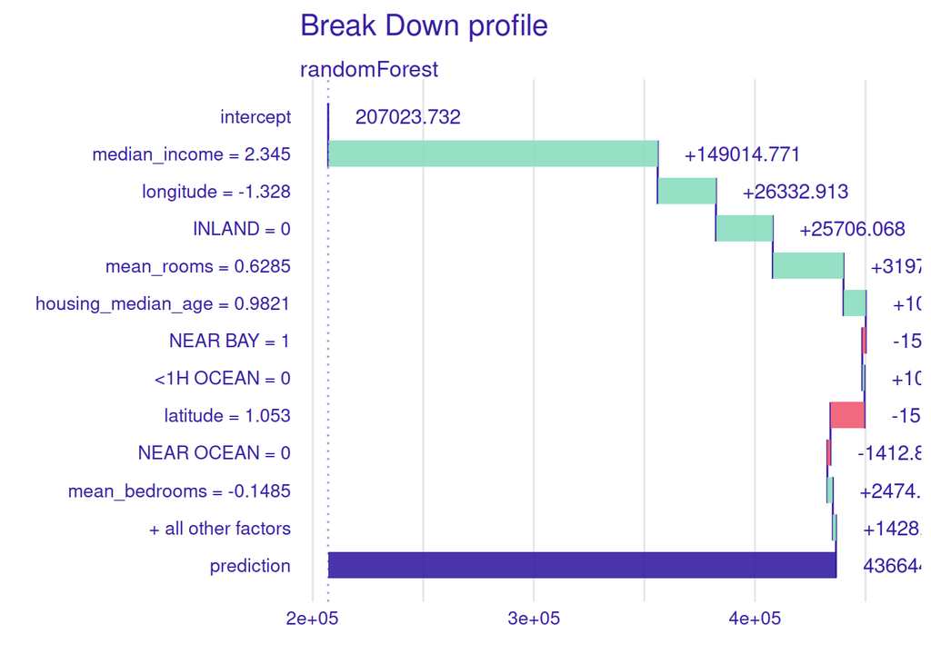

```r
rf_bd_1 <- predict_parts(explainer, new_observation = cleaned_housing[1, -14], type = "break_down")
plot(rf_bd_1)
```

## Dekompozycja shap

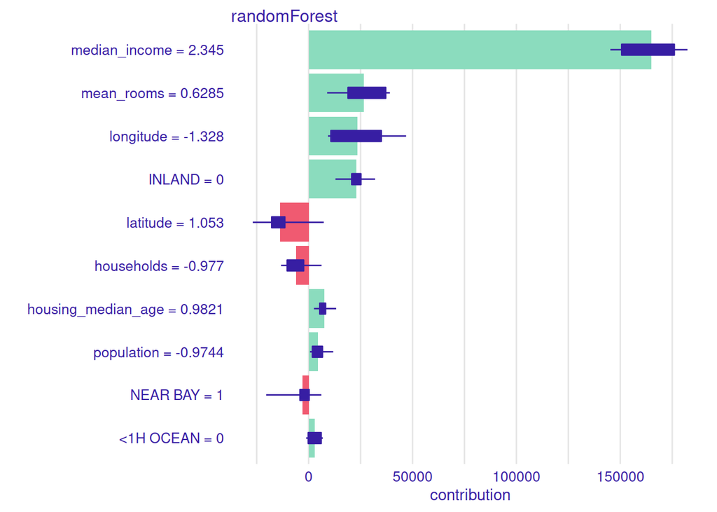

```r
rf_shap <- predict_parts(explainer, new_observation = cleaned_housing[1, -14], type = "shap", B = 10)
plot(rf_shap)
```

Widzimy, że najważniejsze są zmienne średniego dochodu, co świadczy o “poziomie” okolicy oraz średnia liczba pomieszczeń, która oczywiście też jest mocno skorelowana z ceną domu. Dalej jest położenie (szerokość i długość geograficzna) oraz zmienna odnosząca się do położenia względem oceanu. Warto zauważyć, że latitude obniża cenę.

## Obserwacja mająca inne najważniejsze zmienne

```r
rf_bd_2 <- predict_parts(explainer, new_observation = cleaned_housing[5, -14], type = "break_down")

pred_parts_1_sorted <- rf_bd_1[order(-abs(rf_bd_1$contribution)),]
pred_parts_2_sorted <- rf_bd_2[order(-abs(rf_bd_2$contribution)),]


A <- data.frame(pred_parts_1_sorted$variable_name,pred_parts_1_sorted$contribution,pred_parts_2_sorted$variable_name,pred_parts_2_sorted$contribution)
colnames(A) <- c("Obs 1. var. name", "Obs. 1. var. contribiution", "Obs. 2. var. name", "Obs. 2. var. contribiution")

print(A)
```

```
##      Obs 1. var. name Obs. 1. var. contribiution  Obs. 2. var. name
## 1                                   4.366449e+05
## 2           intercept               2.070237e+05          intercept
## 3       median_income               1.490148e+05          longitude
## 4          mean_rooms               3.197997e+04           latitude
## 5           longitude               2.633291e+04             INLAND
## 6              INLAND               2.570607e+04         population
## 7            latitude              -1.540396e+04         households
## 8  housing_median_age               1.006352e+04 housing_median_age
## 9       mean_bedrooms               2.474186e+03           NEAR BAY
## 10           NEAR BAY              -1.574645e+03         NEAR OCEAN
## 11         NEAR OCEAN              -1.412875e+03          <1H OCEAN
## 12          <1H OCEAN               1.012554e+03         mean_rooms
## 13         households               7.176781e+02      median_income
## 14         population               7.108811e+02      mean_bedrooms
```

[output cut: 17 more lines]

```r
print(housing[c(1,5), -14])
```

```
##   longitude latitude housing_median_age population households median_income
## 1   -122.23    37.88                 41        322        126        8.3252
## 5   -122.25    37.85                 52        565        259        3.8462
##   median_house_value ocean_proximity mean_bedrooms mean_rooms
## 1             452600        NEAR BAY      1.023810   6.984127
## 5             342200        NEAR BAY      1.081081   6.281853
```

Jak widzimy dla pierwszej obserwacji najważniejsze są średni przychód i średnia ilość pomieszczeń, natomiast dla drugiej położenie: szerokość i długość geograficzna. Pierwszy rekord opisałem w podpunkcie 2. Druga obserwacja jest 5 z kolei w zbiorze, a przez to jest mocno zbliżona do pierwszej ze względu na położenie (latitude i longitude). Dla drugiej obserwacji zmienne ‘median_income’ i ‘mean_rooms’ mają niższe wartości, prawdopodobnie w związku z czym mają mniejsze contribution. Najwyższy wpływ na predykcje drugiej obserwacji ma długość i szerokość geograficzna.

## Zmienne posiadające przeciwne wpływy

```r
rf_bd_3 <- predict_parts(explainer, new_observation = cleaned_housing[20640, -14])

pred_parts_1_sorted_alf <- rf_bd_1[order(desc(rf_bd_1$variable_name)),]
pred_parts_3_sorted_alf <- rf_bd_3[order(desc(rf_bd_3$variable_name)),]
B <- data.frame(pred_parts_1_sorted_alf$variable_name,pred_parts_1_sorted_alf$contribution,pred_parts_3_sorted_alf$contribution,
                sign(pred_parts_1_sorted_alf$contribution*pred_parts_3_sorted_alf$contribution))
colnames(B) <- c("Var. name", "Contribiution 1", "Contribiution 3", "Sign of multiply")
print(B)
```

```
##             Var. name Contribiution 1 Contribiution 3 Sign of multiply
## 1          population    7.108811e+02    -2760.259594               -1
## 2          NEAR OCEAN   -1.412875e+03    -2330.588275                1
## 3            NEAR BAY   -1.574645e+03     -706.970137                1
## 4       median_income    1.490148e+05   -41023.617658               -1
## 5          mean_rooms    3.197997e+04    -3439.759427               -1
## 6       mean_bedrooms    2.474186e+03    -2264.968192               -1
## 7           longitude    2.633291e+04    28042.139183                1
## 8            latitude   -1.540396e+04   -40895.234546                1
## 9              ISLAND    6.495478e-02       -1.690487               -1
## 10          intercept    2.070237e+05   207023.731939                1
## 11             INLAND    2.570607e+04   -44482.046175               -1
## 12 housing_median_age    1.006352e+04     4649.627657                1
## 13         households    7.176781e+02     1068.574821                1
## 14          <1H OCEAN    1.012554e+03    -8527.111858               -1
## 15                       4.366449e+05    94351.827252                1
```

Teraz wziałem jeden z ostatnich rekordów z tabeli, dzięki czemu nieruchomość ma znacznie inne położenie. Dla wcześniejszych obserwacji te zmienne miały duży wpływ na predykcję, więc stwierdziłem, że duża ich zmiana spowoduje “zamieszanie” w predykcji. Tak się stało i jak widzimy w ostatniej kolumnie tabeli B połowa zmiennych ma przeciwny wpływ (porównując obserwacje 1 i 3).